# Perceptron

## What is Perceptron ??

A Perceptron is a type of artificial neuron, or neural-network unit, that performs computational to identify pattern or features in input data. It is a machine learning algorithm that's used for supervised learning of binary classifiers.

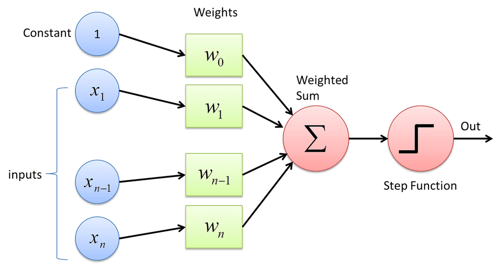

## Basic Componets of Perceptron

[figure not shown]

## 1. Input Layer

**The input layer consists of one or more input neurons, which receives input signals from the external world or from other layers of the neural network.**

## 2. Weights

**Each input neuron is associated with a weight, which represents the strength of the connection between the input neuron and the output neuron.**

## 3. Bias

**A bias term is added to the input layer to provide the perceptron with additional flexibility in modeling complex patterns in the input data.**

## 4. Activation Function

**The activation function determines the output of the perceptron based on the weighted sum of the inputs and the bias term. Common activation functions used in perceptrons include the step function, sigmoid function, and ReLU function.**

## 5. Output

**The output of the perceptron is a single binary value, either 0 or 1, which indicates the class or category to which the input data belongs**

## 6. Training Algorithm

**The perceptron is typically trained using a supervised learning algorithm such as the perceptron learning algorithm or backpropagation. During training, the weights and biases of the perceptron are adjusted to minimize the error between the predicted output and the true output for a given set of training examples.**

**Overall, the perceptron is a simple yet powerful algorithm that can be used to perform binary classification tasks and has paved the way for more complex neural networks used in deep learning today.**

## 1. Single Layer

**Single layer perceptron can learn only linearly separable patterns.**

## 2. Multilayer

**Multilayer perceptrons can learn about two or more layers having a greater processing power.**

**The Perceptron algorithm learns the weights for the input signals in order to draw a linear decision boundary.**

[figure not shown]

### What is Supervised Learning ??

**Supervised Learning is a type of Machine Learning used to learn models from labeled training data. It enables output prediction for future or unseen data.**

## History Of Perceptron

**Perceptron is the nurturing step of an Artificial Neural Link. In 19h century, Mr. Frank Rosenblatt invented the Perceptron to perform specific high-level calculations to detect input data capabilities or business intelligence.**

# 1. Single-Layer Perceptron

## How does perceptron work ??

[figure not shown]

**Perceptron is considered a single-layer neural link with four main parameters. The perceptron model begins with multiplying all input values and their weights, then adds these values to create the weighted sum. Further, this weighted sum is applied to the activation function ‘f’ to obtain the desired output. This activation function is also known as the step function and is represented by ‘f.’**

**This step function or Activation function is vital in ensuring that output is mapped between (0,1) or (-1,1).**

## Step 1:

**Multiply all input values with corresponding weight values and then add to calculate the weighted sum. The following is the mathematical expression of it:**

**`∑wi*xi = x1*w1 + x2*w2 + x3*w3+……..x4*w4`**

**Add a term called bias ‘b’ to this weighted sum to improve the model’s performance.**

## Step 2:

**An activation function is applied with the above-mentioned weighted sum giving us an output either in binary form or a continuous value as follows:**

**`Y=f(∑wi*xi + b)`**

**Activation function simply used in 'step' or 'sigmoid' function.**

- In step function if ∑wi*xi > 0 then output is 1 else 0
- In sigmoid function :
  - first calculate sigmoid values using this formula

[figure not shown]

  - if sigmoid value is greater than 0.5 then 1 else 0

## Perceptron : Decision Function

**A decision function φ(z) of Perceptron is defined to take a linear combination of x and w vectors.**

[figure not shown]

**Where w and x respectively weights and input vectors**

**The value z is the decision function is given by:**

[figure not shown]

**The decision function is +1 if z is greater than a threshold θ, and it is -1 otherwise.**

[figure not shown]

### This is the Perceptron algorithm.

## Bias Unit

**For simplicity, the threshold θ can be brought to the left and represented as w0x0, where w0= -θ and x0= 1.**

[figure not shown]

**The value w0 is called the bias unit.**

**The decision function then becomes:**

[figure not shown]

## Output

**The figure shows how the decision function squashes wTx to either +1 or -1 and how it can be used to discriminate between two linearly separable classes.**

[figure not shown]

## Perceptron Learning -- How to train a perceptron ??

## step 1 :

  `new_weight = old_weight - learning_rate * gradient_of_weight`

  `new_bias = old_bias - learning_rate * gradient_of_bias`

## Perceptron Algorithm Implementation In Python

```python
class Perceptron:
    def __init__(self):
        self.coef_= None
        self.intercept_ = None

    def fit(self,X,y):
       ## add 1 into input
       X = np.insert(X,0,1,axis=1)
       ## intialize weights and bias -- 1
       weights = np.ones(X.shape[1])
       ## set learning rate
       lr = 0.1
       ## run epochs
       for i in range(1000):
           # randomly select a data point
           j = np.random.randint(0,X.shape[0])
           ## calculate y_hat
           y_hat = np.dot(X[j],weights)
           ## apply step function -- activation function
           if y_hat > 0:
               y_hat = 1
           else:
               y_hat = 0
           ## update weights and bias
           weights = weights +  lr * (y[j]-y_hat) * X[j]

       self.intercept_ = weights[0]
       self.coef_ = weights[1:]
       return self.coef_,self.intercept_

    def predict(self,X):
       return X * self.coef_ + self.intercept_
```

## Test Algorithm

### 1. Genrate an dataset for test algorithm

```python
from sklearn.datasets import make_classification
import pandas as pd
import numpy as np

## generate data
X,y = make_classification(n_samples=100,n_features=2,n_classes=2,n_clusters_per_class=1,class_sep=2,n_redundant=0,n_informative=1)

pd.DataFrame({
    'X1':X[:,0],
    'X2':X[:,1],
    'y':y
})
```

|  | X1 | X2 | y |
| --- | --- | --- | --- |
| 0 | -2.106362 | 0.068844 | 0 |
| 1 | 1.963878 | -0.612770 | 1 |
| 2 | 1.357535 | -1.675561 | 1 |
| 3 | -1.911365 | -0.867609 | 0 |
| 4 | -2.090640 | 1.351313 | 0 |
| ... | ... | ... | ... |
| 95 | 2.336639 | 0.816396 | 1 |
| 96 | -1.709082 | 1.222131 | 0 |
| 97 | 3.035898 | -0.429570 | 1 |
| 98 | -2.329571 | -0.223784 | 0 |
| 99 | 2.970216 | 0.417816 | 1 |

100 rows × 3 columns

### 2. Plot the data

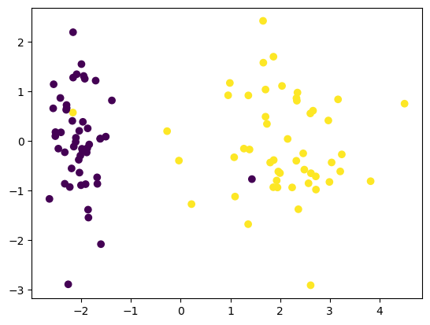

```python
import matplotlib.pyplot as plt
plt.scatter(X[:,0],X[:,1],c=y)
```

## 3. Test Algorithm

```python
pt = Perceptron()
```

```python
pt.fit(X,y)
```

```
(array([0.47352658, 0.17521043]), 0.30000000000000016)
```

```python
y_pred = pt.predict(X)
```

## 4. Plot Decision Boundary

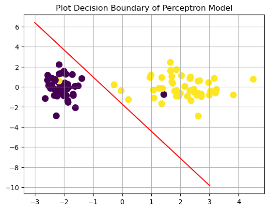

```python
## calculate m and b
m = -(pt.coef_[0]/pt.coef_[1])
b = -(pt.intercept_/pt.coef_[1])

## generate data points for predictions
x_input = np.linspace(-3,3,100)
## predicts the output for generated data points
y_input = m * x_input + b

## plot output line

plt.scatter(X[:,0],X[:,1],c=y,s=50,linewidths=3)
plt.plot(x_input,y_input,c='red')
plt.title('Plot Decision Boundary of Perceptron Model')
plt.grid()
plt.show()
```

## Scikit-Learn Implemenation Perceptron

```python
from sklearn.linear_model import Perceptron

pt = Perceptron()
# train model
pt.fit(X,y)
```

```
Perceptron()
```

## Plot Decison Boundary

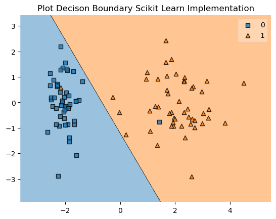

```python
from mlxtend.plotting import plot_decision_regions
plot_decision_regions(X[:,0:2],y,clf=pt)
plt.title('Plot Decison Boundary Scikit Learn Implementation')
plt.show()
```

## Advantages of Perceptron

- It works well both small and large input data.
- Helps us to obtain quick predictions after training data.
- Helps us to obtain the same accuracy ratio with big and small data.

## Disdvantages

- The model functioning depends on the quality of training.
- It is tough to predict how much the dependent variable affects each independent variable.

## Limitation Of Perceptron Model

**The following are the limitation of a Perceptron model:**

- The output of a perceptron can only be a binary number (0 or 1) due to the hard-edge transfer function.
- It can only be used to classify the linearly separable sets of input vectors. If the input vectors are non-linear, it is not easy to classify them correctly.

## Problems With Perceptron (single_layer perceptron)

## It does not captures non-linear data as well

## Example

```python
from sklearn.datasets import make_circles
import matplotlib.pyplot as plt

## genrate non-linear data
X,y = make_circles(n_samples=100,shuffle=True,noise=0.2,)
```

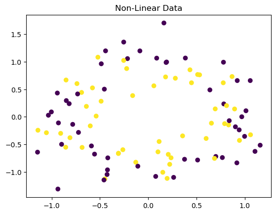

```python
## Plot Non-Linear data
plt.scatter(X[:,0],X[:,1],c=y)
plt.title('Non-Linear Data')
plt.show()
```

## Train Perceptron Model

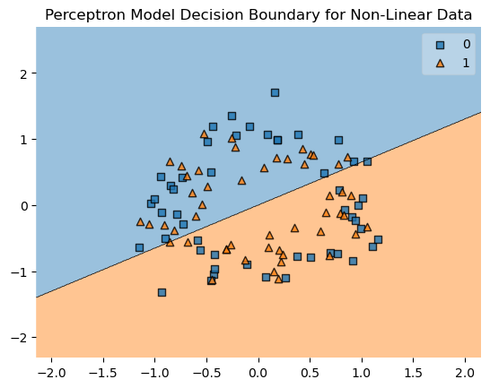

```python
from sklearn.linear_model import Perceptron
from mlxtend.plotting import plot_decision_regions

pt = Perceptron()
## train model
pt.fit(X,y)

## plot decision boundary
plot_decision_regions(X[:,0:2],y,clf=pt)
plt.title('Perceptron Model Decision Boundary for Non-Linear Data')
plt.show()
```

## You Noticed that Perceptron Model Does not Correctly Classify Non-Linear data.

## Solution -- In Next Class ......

[figure not shown]

## Keep Learning , Never Give Up !!!!